# Data Science Project(Clustering)

Groupt-04

2026-01-01

#### Dataset: Student Performance Factors

#### Source: Kaggle

#### Link: https://drive.google.com/uc?export=download&id=1IWA5bJ8t7s0pJKCGah4Fg4xVEFWS1SD5

#### Domain: Education

#### Objective:Group students into similar performance-behavior profiles

### Load required packages for data handling, visualization and modeling

Packages are installed automatically if not available to ensure portability.

```r
packages<-c("ggplot2","dplyr","tidyr","GGally","e1071","fastDummies","corrplot","cluster","factoextra","caret","FactoMineR")
installed<-rownames(installed.packages())
for(p in packages){
  if(!(p %in% installed)) install.packages(p)
  library(p, character.only = TRUE)
}
```

# A.Data Collection

### Load dataset directly from URL to avoid local file dependency

This ensures the script runs on any machine without modification and Print dataset

```r
url<-"https://drive.google.com/uc?export=download&id=1IWA5bJ8t7s0pJKCGah4Fg4xVEFWS1SD5"
data<-read.csv(url)
head(data)
```

```
##   Hours_Studied Attendance Parental_Involvement Access_to_Resources
## 1            23         84                  Low                High
## 2            19         64                  Low              Medium
## 3            24         98               Medium              Medium
## 4            29         89                  Low              Medium
## 5            19         92               Medium              Medium
## 6            19         88               Medium              Medium
##   Extracurricular_Activities Sleep_Hours Previous_Scores Motivation_Level
## 1                         No           7              73              Low
## 2                         No           8              59              Low
## 3                        Yes           7              91           Medium
## 4                        Yes           8              98           Medium
## 5                        Yes           6              65           Medium
## 6                        Yes           8              89           Medium
##   Internet_Access Tutoring_Sessions Family_Income Teacher_Quality School_Type
```

[output cut: 20 more lines]

# B.Data understanding and Exploration

### To determine how many rows and columns in this dataset

```r
cat("Rows:",nrow(data),"Columns:",ncol(data),"\n")
```

[output not shown]

### The structure and data types of this dataset

```r
str(data)
```

```
## 'data.frame':    6607 obs. of  20 variables:
##  $ Hours_Studied             : int  23 19 24 29 19 19 29 25 17 23 ...
##  $ Attendance                : int  84 64 98 89 92 88 84 78 94 98 ...
##  $ Parental_Involvement      : chr  "Low" "Low" "Medium" "Low" ...
##  $ Access_to_Resources       : chr  "High" "Medium" "Medium" "Medium" ...
##  $ Extracurricular_Activities: chr  "No" "No" "Yes" "Yes" ...
##  $ Sleep_Hours               : int  7 8 7 8 6 8 7 6 6 8 ...
##  $ Previous_Scores           : int  73 59 91 98 65 89 68 50 80 71 ...
##  $ Motivation_Level          : chr  "Low" "Low" "Medium" "Medium" ...
##  $ Internet_Access           : chr  "Yes" "Yes" "Yes" "Yes" ...
##  $ Tutoring_Sessions         : int  0 2 2 1 3 3 1 1 0 0 ...
##  $ Family_Income             : chr  "Low" "Medium" "Medium" "Medium" ...
##  $ Teacher_Quality           : chr  "Medium" "Medium" "Medium" "Medium" ...
##  $ School_Type               : chr  "Public" "Public" "Public" "Public" ...
##  $ Peer_Influence            : chr  "Positive" "Negative" "Neutral" "Negative" ...
##  $ Physical_Activity         : int  3 4 4 4 4 3 2 2 1 5 ...
##  $ Learning_Disabilities     : chr  "No" "No" "No" "No" ...
##  $ Parental_Education_Level  : chr  "High School" "College" "Postgraduate" "High School" ...
##  $ Distance_from_Home        : chr  "Near" "Moderate" "Near" "Moderate" ...
##  $ Gender                    : chr  "Male" "Female" "Male" "Male" ...
##  $ Exam_Score                : int  67 61 74 71 70 71 67 66 69 72 ...
```

### Descriptive Statistical Analysis of the dataset

```r
summary(data)
```

```
##  Hours_Studied     Attendance     Parental_Involvement Access_to_Resources
##  Min.   : 1.00   Min.   : 60.00   Length:6607          Length:6607
##  1st Qu.:16.00   1st Qu.: 70.00   Class :character     Class :character
##  Median :20.00   Median : 80.00   Mode  :character     Mode  :character
##  Mean   :19.98   Mean   : 79.98
##  3rd Qu.:24.00   3rd Qu.: 90.00
##  Max.   :44.00   Max.   :100.00
##  Extracurricular_Activities  Sleep_Hours     Previous_Scores
##  Length:6607                Min.   : 4.000   Min.   : 50.00
##  Class :character           1st Qu.: 6.000   1st Qu.: 63.00
##  Mode  :character           Median : 7.000   Median : 75.00
##                             Mean   : 7.029   Mean   : 75.07
##                             3rd Qu.: 8.000   3rd Qu.: 88.00
##                             Max.   :10.000   Max.   :100.00
##  Motivation_Level   Internet_Access    Tutoring_Sessions Family_Income
##  Length:6607        Length:6607        Min.   :0.000     Length:6607
##  Class :character   Class :character   1st Qu.:1.000     Class :character
##  Mode  :character   Mode  :character   Median :1.000     Mode  :character
##                                        Mean   :1.494
##                                        3rd Qu.:2.000
##                                        Max.   :8.000
##  Teacher_Quality    School_Type        Peer_Influence     Physical_Activity
##  Length:6607        Length:6607        Length:6607        Min.   :0.000
##  Class :character   Class :character   Class :character   1st Qu.:2.000
##  Mode  :character   Mode  :character   Mode  :character   Median :3.000
##                                                           Mean   :2.968
##                                                           3rd Qu.:4.000
##                                                           Max.   :6.000
##  Learning_Disabilities Parental_Education_Level Distance_from_Home
##  Length:6607           Length:6607              Length:6607
##  Class :character      Class :character         Class :character
##  Mode  :character      Mode  :character         Mode  :character
##
##
##
##     Gender            Exam_Score
##  Length:6607        Min.   : 55.00
##  Class :character   1st Qu.: 65.00
##  Mode  :character   Median : 67.00
##                     Mean   : 67.24
##                     3rd Qu.: 69.00
##                     Max.   :101.00
```

### Separation of Features into Numerical and Categorical Categories

```r
num_cols<-names(data)[sapply(data,is.numeric)]
cat_cols<-names(data)[!sapply(data,is.numeric)]
cat("Numerical:",num_cols, "\n")
```

```
## Numerical: Hours_Studied Attendance Sleep_Hours Previous_Scores Tutoring_Sessions Physical_Activity Exam_Score
```

```r
cat("Categorical:",cat_cols, "\n")
```

```
## Categorical: Parental_Involvement Access_to_Resources Extracurricular_Activities Motivation_Level Internet_Access Family_Income Teacher_Quality School_Type Peer_Influence Learning_Disabilities Parental_Education_Level Distance_from_Home Gender
```

### Histogram

Visualization of histogram of numerical columns where each histogram shows how frequently different values occur within a numeric column

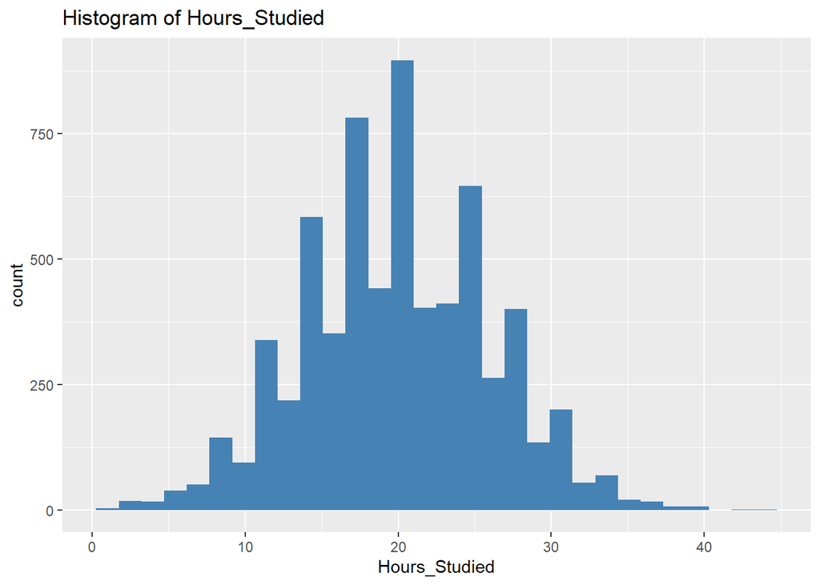

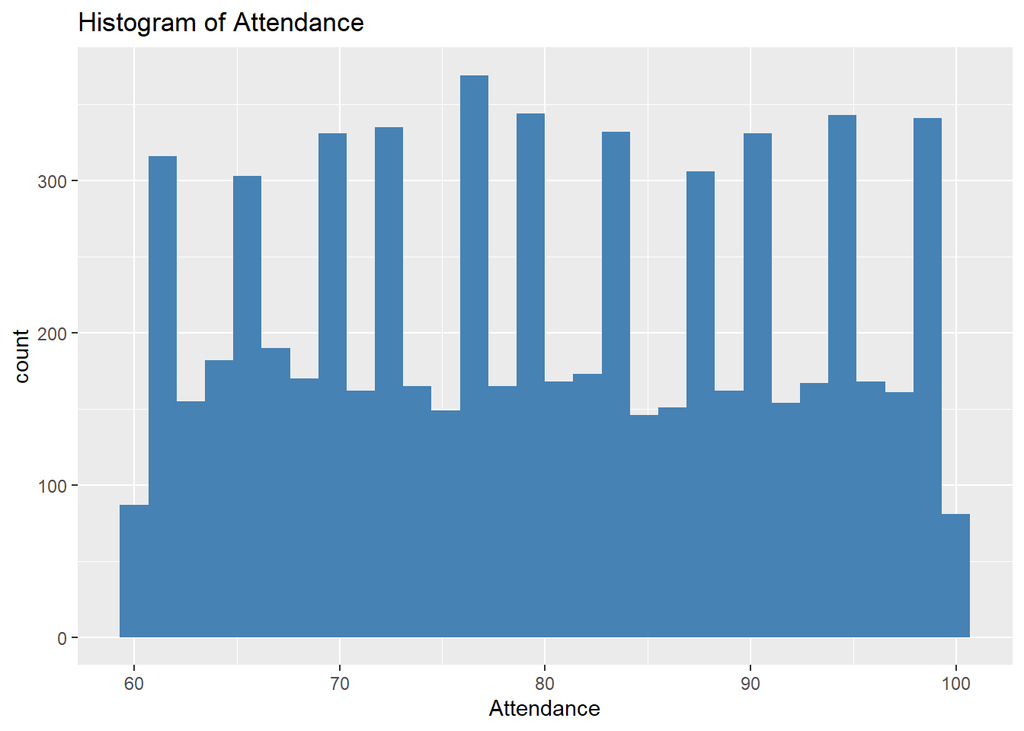

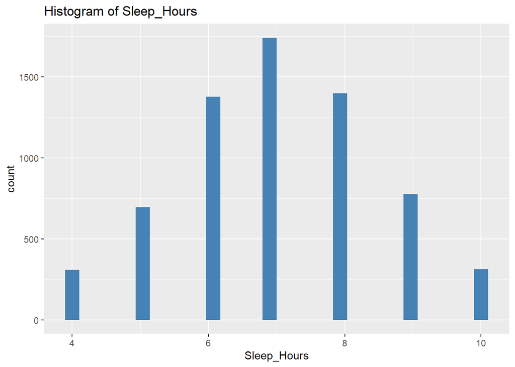

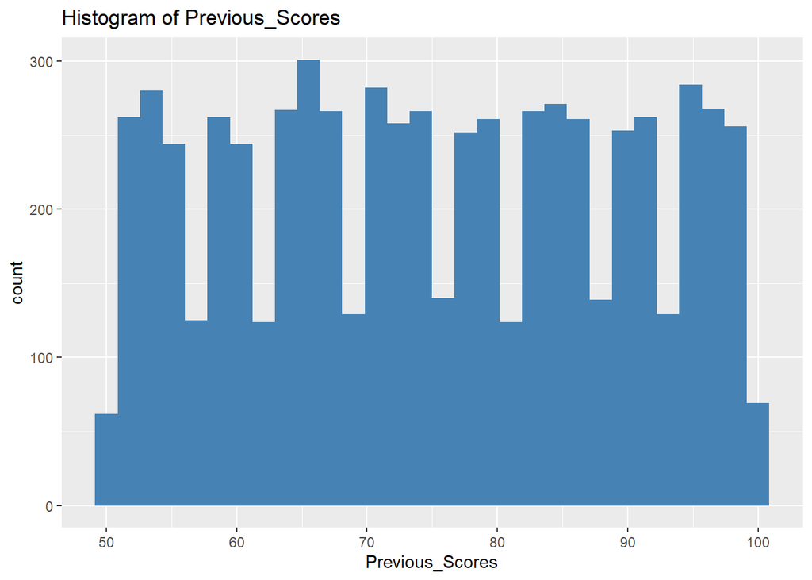

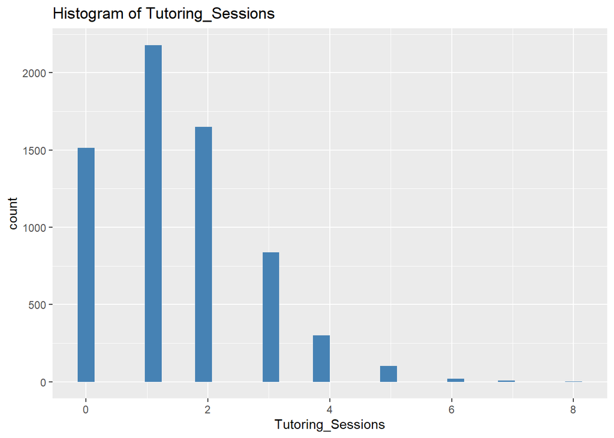

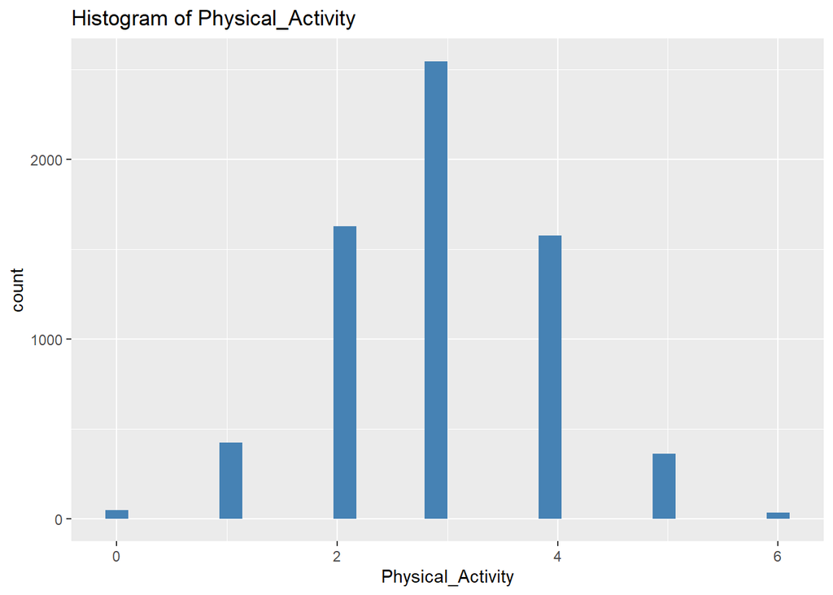

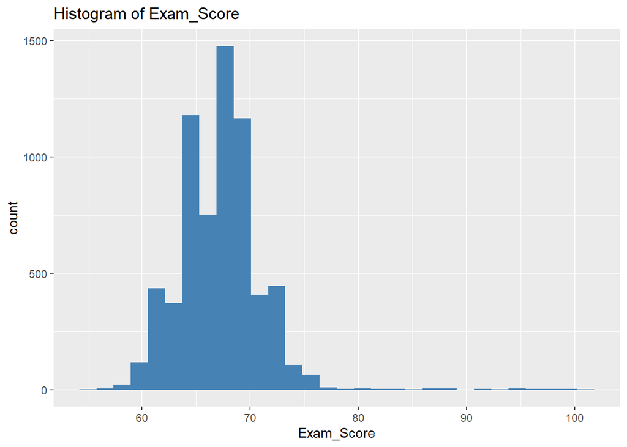

```r
for(col in num_cols){
  print(ggplot(data,aes_string(x=col)) +
          geom_histogram(fill="steelblue") +
          labs(title=paste("Histogram of",col)))
}
```

### Box-plot

Visualization of boxplot of numerical columns where boxplots show the distribution of each numeric variable, highlighting the median, spread and any outliers in the dataset

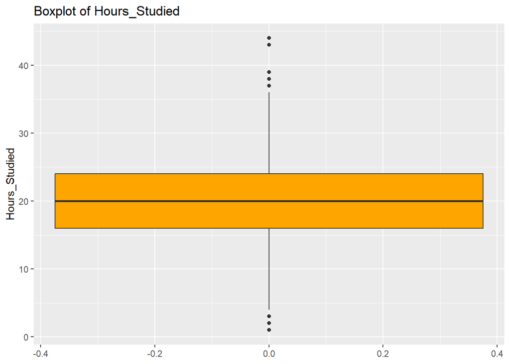

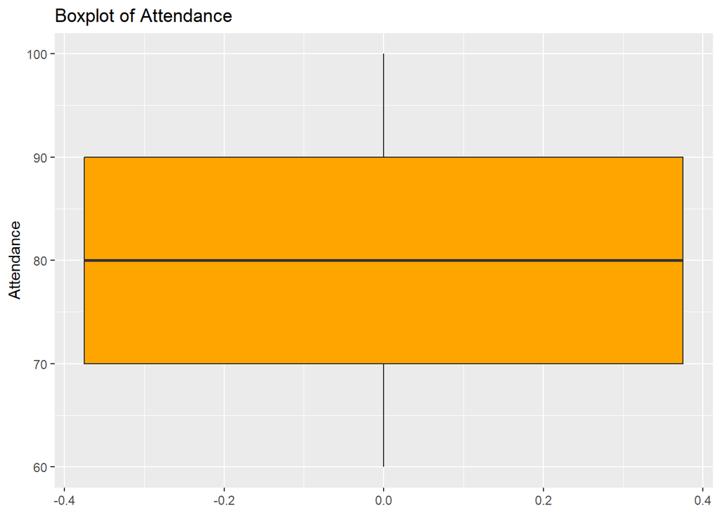

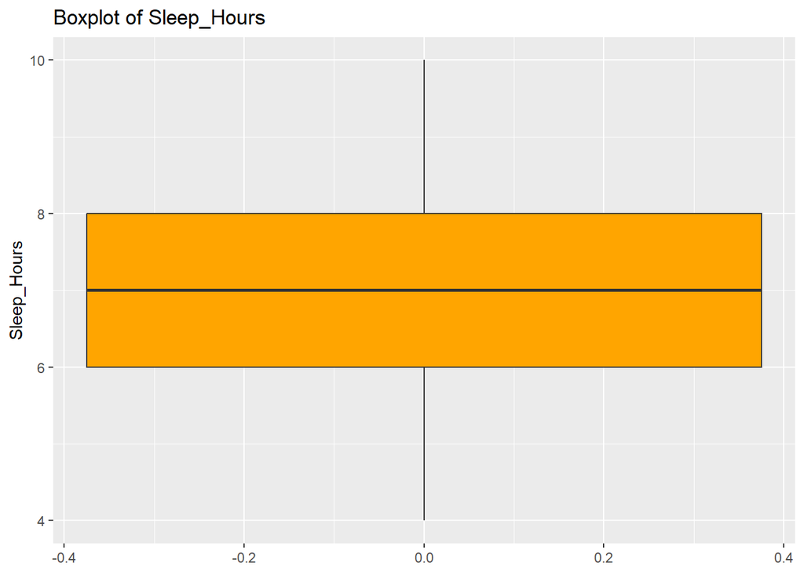

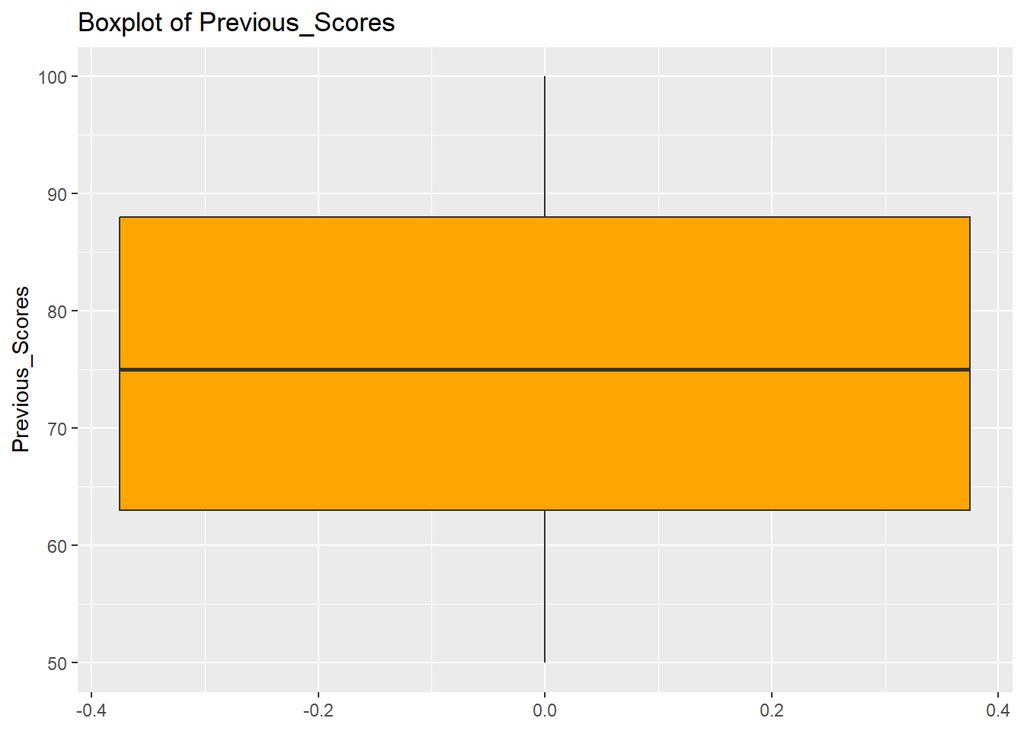

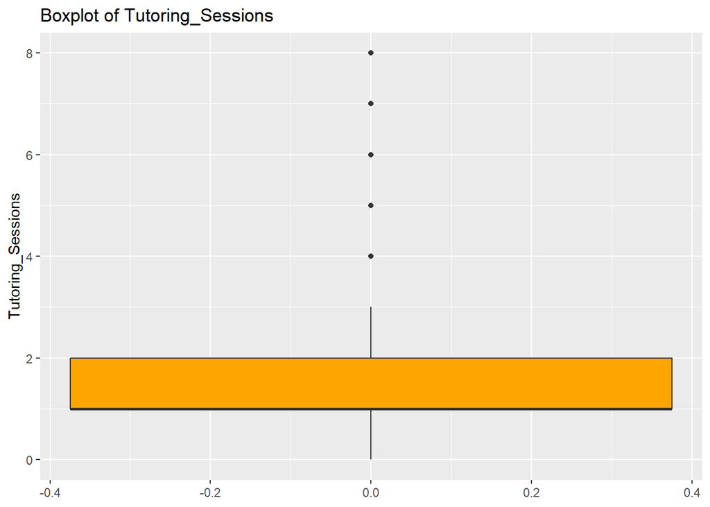

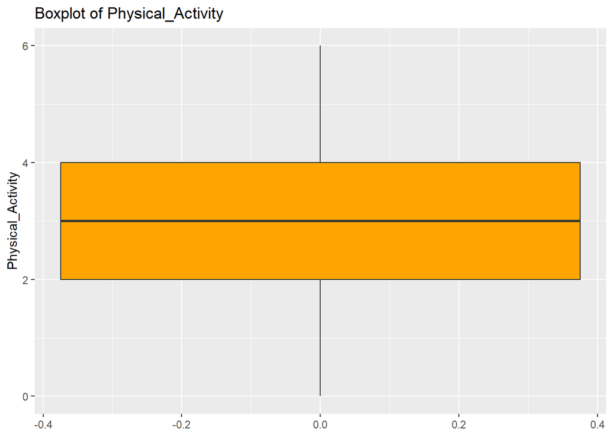

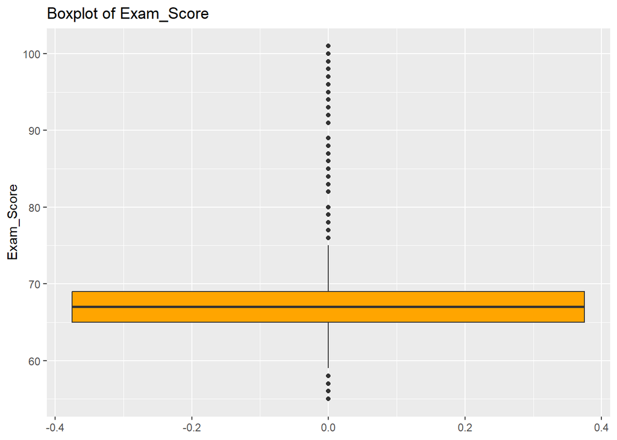

```r
for(col in num_cols){
  print(ggplot(data,aes_string(y=col)) +
          geom_boxplot(fill="orange") +
          labs(title=paste("Boxplot of", col)))
}
```

### Heatmap

Visualization of heatmap and heatmap shows the correlations between numeric variables in the dataset, using color intensity to indicate the strength and direction of the relationships

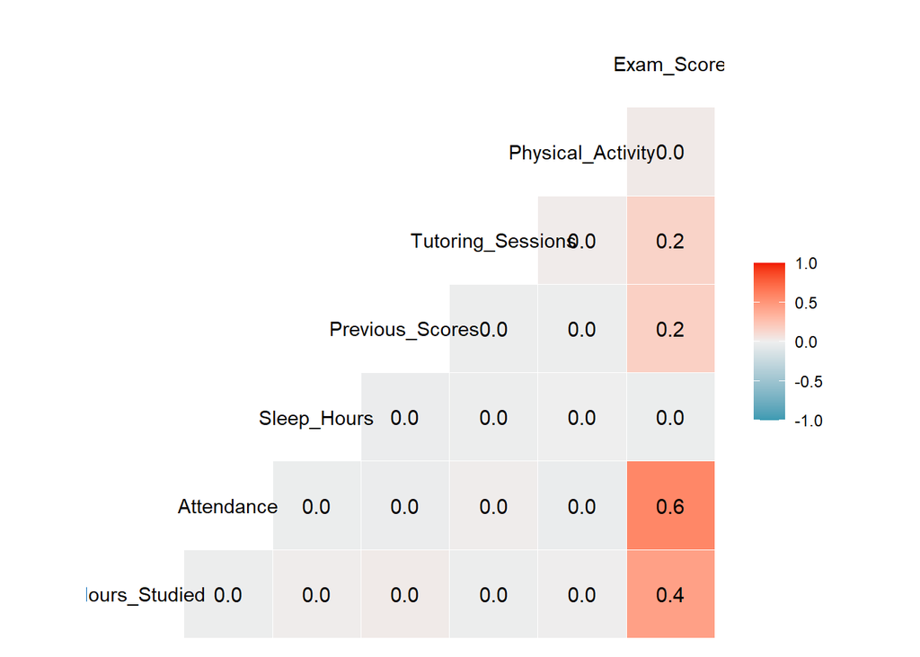

```r
ggcorr(data,label=TRUE)+
  theme(
    axis.text.x=element_text(angle=45,hjust=1)
  )
```

### Scatter-plot

Visualization of scatter plot and scatter plot matrix shows pairwise relationships between the key numeric variables in the dataset. Points are colored by the Gender variable when available

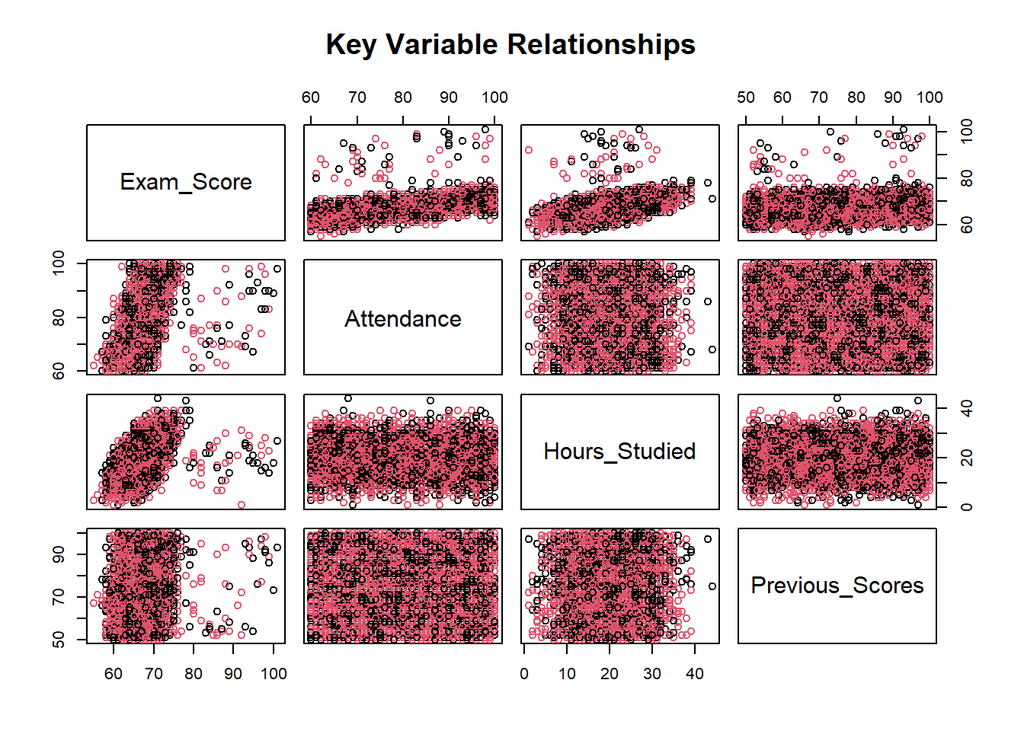

```r
num_data <- data[sapply(data, is.numeric)]
num_data <- num_data[, sapply(num_data, function(x) length(unique(x)) < 0.9 * nrow(num_data))]
cor_mat <- cor(num_data, use = "complete.obs")
avg_cor <- apply(abs(cor_mat), 1, mean)
selected_vars <- names(sort(avg_cor, decreasing = TRUE))[1:4]
colors <- if ("Gender" %in% names(data)) {
  as.numeric(as.factor(data$Gender))
} else {
  "black"
}
pairs(data[, selected_vars],
      main = "Key Variable Relationships",
      col = colors)
```

### Identify number of NA value

```r
data[data == ""] <- NA
print(colSums(is.na(data)))
```

```
##              Hours_Studied                 Attendance
##                          0                          0
##       Parental_Involvement        Access_to_Resources
##                          0                          0
## Extracurricular_Activities                Sleep_Hours
##                          0                          0
##            Previous_Scores           Motivation_Level
##                          0                          0
##            Internet_Access          Tutoring_Sessions
##                          0                          0
##              Family_Income            Teacher_Quality
##                          0                         78
##                School_Type             Peer_Influence
##                          0                          0
##          Physical_Activity      Learning_Disabilities
##                          0                          0
##   Parental_Education_Level         Distance_from_Home
##                         90                         67
##                     Gender                 Exam_Score
##                          0                          0
```

# C. Data Preprocessing

### Handle Missing Values

For Numeric Variable, use median value

```r
num_cols <- sapply(data, is.numeric)
for(col in names(data)[num_cols]){
  data[[col]][is.na(data[[col]])] <- median(data[[col]], na.rm = TRUE)
}
```

For Categorical Variable, use mode value

```r
cat_cols <- sapply(data, is.character)
get_mode <- function(x){
  ux <- na.omit(unique(x))
  ux[which.max(tabulate(match(x, ux)))]
}
for(col in names(data)[cat_cols]){
  data[[col]][is.na(data[[col]])] <- get_mode(data[[col]])
}
```

### Remove duplicate variable

```r
data<-data[!duplicated(data), ]
cat("\nMissing values after handle missing values and remove duplicate values:\n")
```

```
##
## Missing values after handle missing values and remove duplicate values:
```

```r
print(colSums(is.na(data)))
```

```
##              Hours_Studied                 Attendance
##                          0                          0
##       Parental_Involvement        Access_to_Resources
##                          0                          0
## Extracurricular_Activities                Sleep_Hours
##                          0                          0
##            Previous_Scores           Motivation_Level
##                          0                          0
##            Internet_Access          Tutoring_Sessions
##                          0                          0
##              Family_Income            Teacher_Quality
##                          0                          0
##                School_Type             Peer_Influence
##                          0                          0
##          Physical_Activity      Learning_Disabilities
##                          0                          0
##   Parental_Education_Level         Distance_from_Home
##                          0                          0
##                     Gender                 Exam_Score
##                          0                          0
```

### One-hot coding

One-hot encoding converts categorical variables into numeric binary columns, where each category is represented by a separate column with 0 or 1 values

```r
data<-dummyVars(" ~ .",data=data) %>% predict(newdata=data) %>% as.data.frame()
```

### Salling

Scaling standardizes numeric variables so that each has a mean of 0 and a standard deviation of 1

```r
data_scaled<-scale(data)
```

### Skewness

Skewness correction identifies numeric variables that are highly skewed (skewness > 1) and applies a log transformation to reduce skewness

```r
skewed<-apply(data_scaled,2,function(x) abs(e1071::skewness(x))>1)
data_scaled[, skewed] <- log1p(abs(data_scaled[, skewed]))
```

### PCA

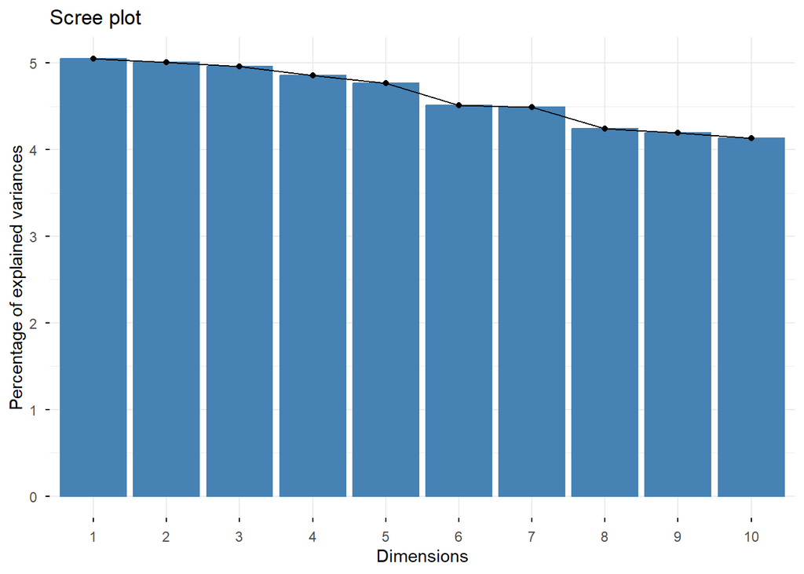

```r
pca_res<-prcomp(data_scaled,scale.=TRUE)
fviz_eig(pca_res)
```

### Selects the first four principal components from the PCA results to use for clustering

```r
pc_data<-pca_res$x[, 1:4]
```

### Within-cluster sum of squres

Code computes the total within-cluster sum of squares (WSS) for different numbers of clusters (k = 1 to 20) to help determine the optimal number of clusters using the Elbow Method

```r
wss<-c()
for(k in 1:20){
  set.seed(123)
  km_model<-kmeans(pc_data,centers=k,nstart=25)
  wss[k]<-km_model$tot.withinss
}
```

### Elbow Method

This plot visualizes the total within-cluster sum of squares (WSS) for different numbers of clusters. The ‘elbow’ point helps identify the optimal number of clusters for K-means

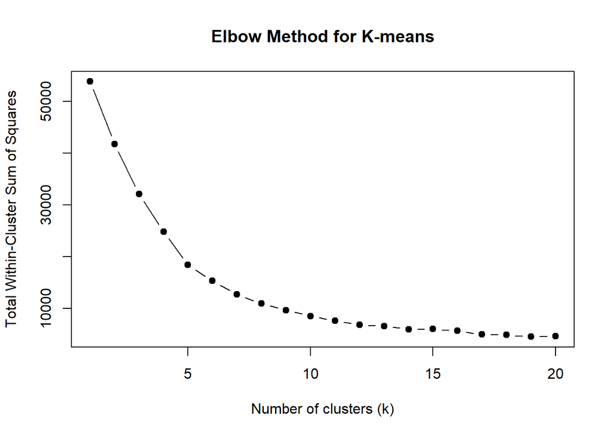

```r
plot(1:20,wss,type="b",pch=19,
     xlab="Number of clusters (k)",
     ylab="Total Within-Cluster Sum of Squares",
     main="Elbow Method for K-means")
```

### Best K based on Silhoute score

Code calculates the average silhouette score for different numbers of clusters (k = 2 to 20) to evaluate cluster quality. The number of clusters with the highest silhouette score is chosen as the best k for K-means

```r
sil_scores<-c()
for(k in 2:20){
  set.seed(123)
  km_model<-kmeans(pc_data,centers=k,nstart=25)
  sil<-silhouette(km_model$cluster,dist(pc_data))
  sil_scores[k]<-mean(sil[,3])
}

sil_scores<-sil_scores[2:20]
best_k<-which.max(sil_scores)+1
cat("Best K based on silhouette score:",best_k, "\n")
```

```
## Best K based on silhouette score: 14
```

### Silhouette Analysis

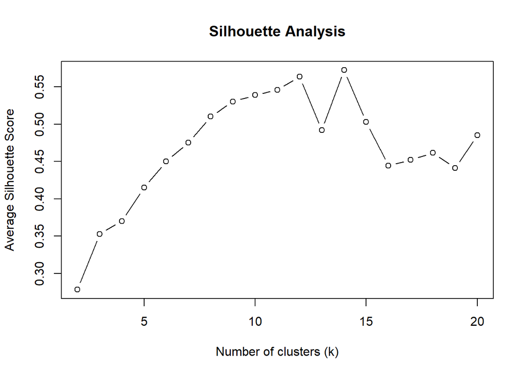

```r
plot(2:20, sil_scores, type="b", xlab="Number of clusters (k)",
     ylab="Average Silhouette Score", main="Silhouette Analysis")
```

# D. Modeling

### k-means clustering

```r
set.seed(123)
final_km<-kmeans(pc_data,centers=best_k,nstart=50)
```

# E.Evaluation

### Average silhoutte score

```r
final_sil <- silhouette(final_km$cluster, dist(pc_data))
cat("Average silhouette score for final model:", mean(final_sil[,3]), "\n")
```

```
## Average silhouette score for final model: 0.5724904
```

### Evaluation with cluster plot

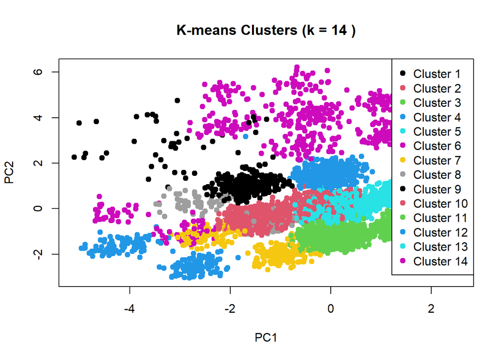

```r
plot(pc_data[,1], pc_data[,2], col=final_km$cluster, pch=19,
     xlab="PC1", ylab="PC2", main=paste("K-means Clusters (k =", best_k, ")"))
legend("topright", legend=paste("Cluster", 1:best_k), col=1:best_k, pch=19)
```